# Weed community structure in upland farming system of the middle mountain region in far-western Nepal - ScienceDirect

[figure not shown]

## Outline

1. Highlights
2. Abstract
3. Keywords
4. 1. Introduction
5. 2. Materials and methods
6. 3. Results
7. 4. Discussion
8. 5. Conclusions
9. Funding
10. Declaration of Competing Interest
11. Acknowledgements
12. Appendix A. Supplementary data
13. References

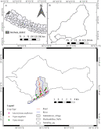

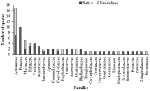

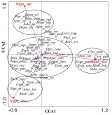

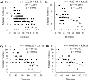

## Extras (3)

1. Supplementary material: Supplementary figure 1. Plot layout in the study area.
2. Supplementary material: Supplementary figure 2. Variation of weed species richness (#species/m2) with weed biomass (g/m2)
3. Supplementary material: Supplementary table 1. List of plants species.

[figure not shown]

## [Acta Ecologica Sinica](https://www.sciencedirect.com/journal/acta-ecologica-sinica)

Available online 20 May 2022

[In Press, Corrected Proof](https://www.sciencedirect.com/journal/acta-ecologica-sinica/articles-in-press)

# Weed community structure in upland farming system of the middle mountain region in far-western Nepal

[Mahesh RajBist](https://www.sciencedirect.com/science/article/abs/pii/S1872203222000245#!)[Bharat BabuShrestha](https://www.sciencedirect.com/science/article/abs/pii/S1872203222000245#!)

https://doi.org/10.1016/j.chnaes.2022.05.002[Get rights and content](https://s100.copyright.com/AppDispatchServlet?publisherName=ELS&contentID=S1872203222000245&orderBeanReset=true)

## Highlights

**•**

Weed community of legume crop field analyzed in a mountain village of north-west Nepal.

**•**

Asteraceae was the most species-rich family.

**•**

Invasive species *Ageratum houstonianum* dominated the weed community.

**•**

Weed species richness declined with increasing biomass of *A. houstonianum.*

## Abstract

Weeds are recognized worldwide as an important environmental and economic burden in the human dominated landscape, particularly in the agro-ecosystems. Management of weeds is highly context specific and requires the knowledge of weed community structure at local levels. Additionally, periodic assessment of weed flora is essential because the weed community structure modifies over time due to changes in cropping patterns and arrival of invasive alien weeds. In this study we assessed the agricultural weed flora and weed community structure in legume fields (*Macrotyloma uniflorum, Vigna angularis* and *Vigna mungo* crops) dominated by invasive weed *Ageratum houstonianum* in a remote mountain village Gokuleshwor of Darchula district in north-west Nepal. Weed flora of the study area was inventoried by transect walk method and weed community structure in three crop fields were analyzed by quadrat sampling. We recorded 75 vascular plant species belonging to 67 genera and 29 families as agricultural weeds. Among them, 21 species (28%) were alien species naturalized in Nepal and 9 of these naturalized species were invasive. Asteraceae (18 species) was the most species-rich family, followed by Poaceae (10 species) and Malvaceae (5 species). Out of 75 weed species, 65 were also listed in the World Compendium of Weed. *A. houstonianum* had the highest biomass and the importance percentage in all three crop fields. Weed species richness and *A. houstonianum* biomass did not vary significantly among the three crop fields. The weed species richness significantly declined with increasing *A. houstonianum* biomass. The results suggest that the alien species contributed significantly to the weed flora of the upland farming system and an invasive weed became a dominant species of the weed community. Control of such weeds at their early stage of invasions can prevent them from becoming dominant weeds and protect the crop production systems from their negative impacts.

## Keywords

*Ageratum houstonianum*

Agricultural weed

Darchula district

Invasive alien species

Legume

© 2022 Ecological Society of China. Published by Elsevier B.V. All rights reserved.

[figure not shown]